**EAGLE 1.0**: *Quick Start Guide*  
**Andrew W. George,**  
**Data61, CSIRO, Australia**

# **Getting Started**

To install the Eagle package, from an interactive session in [R](https://www.r-project.org/about.html), type the command

```r
install.packages("Eagle")
```

Once installed, the package is loaded into R with

```r
library("Eagle")
```

and you will see a message saying that Eagle has been loaded.

# **Running Eagle via the UI**

The easiest way of interacting with Eagle and performing an analysis is through our web-based user interface (UI). To run the UI, at the R prompt, type

```r
OpenUI()
```

which will open the default web browser to the Eagle UI.

# **Reading in the Marker Data**

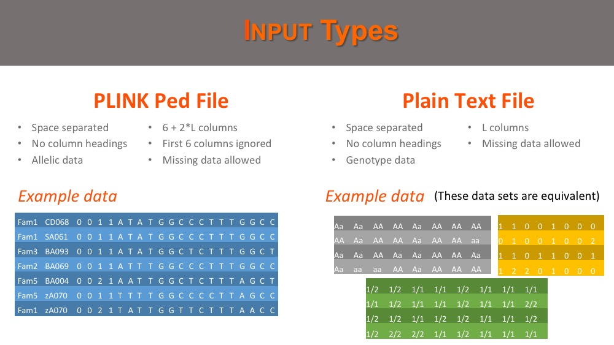

## Reading in a PLINK Ped File

[figure not shown]

## Reading in a Text File

[figure not shown]

# **Reading in the Phenotypic Data**

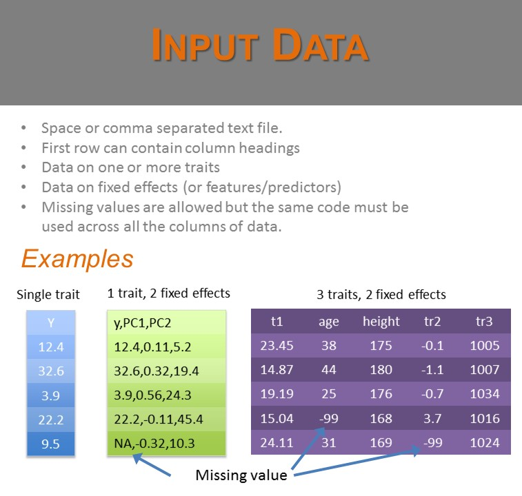

[figure not shown]

# **Reading in the Marker Map**

[figure not shown]

[figure not shown]

# **Analysing the Data**

## Scenario 1: Phenotype data on single trait, no fixed effects

[figure not shown]

## Scenario 2: Phenotype data on three traits and two fixed effects. Trait of interest “y2”. Fixed effects to be included in model are “pc1” and “pc2”

[figure not shown]

# **Findings**

[figure not shown]

# **Where to Go for Help**

- The UI has built-in help. By hovering over any of the input widgets, a popup help box appears
- Detailed help is available on every page. Just hover the cursor over the Details bar and a popup box with a detailed description will appear.
- At the top of any page is the Help tab. By clicking on this tab, a menu of items appears. Frequently asked questions, and other documents such as a worked example can be accessed.
- Youtube videos have been created on how to install Eagle, and how to perform a genome-wide analysis.
- Email your question to `eaglehelp@csiro.au`